# Credit Card Fraud Analysis: Geographic and Merchant Risk Assessment

William Matthews

October 02, 2025

Report generated on: October 02, 2025 at 11:05:28

## Project Overview & Methodology

**Objective:** Analyze credit card fraud patterns to identify high-risk geographic regions and merchants, enabling data-driven fraud prevention strategies.

**Analysis Framework:** - Geographic risk assessment across states with statistical validation - Merchant-level fraud pattern identification - Temporal trend analysis to understand fraud dynamics - Bayesian statistical methods to account for sample size variations - Data quality assessment and limitation documentation

**Key Questions Addressed:** - Which geographic regions demonstrate the highest fraud risk? - Which merchants exhibit elevated fraud patterns requiring enhanced monitoring? - What temporal patterns can inform dynamic resource allocation? - How do we ensure statistical reliability while managing sample size effects?

## Data Loading and Geographic Enrichment

**Purpose:** Load the credit card fraud dataset and enrich it with state-level geographic information to enable regional risk analysis.

**Methodology:** We combine the original fraud dataset with geographic lookup data to map transaction cities to their corresponding states. This enrichment is essential for conducting meaningful geographic analysis while preserving original merchant names for accurate business intelligence.

```r
# Load original and enriched datasets
creditCardFraud <- read_csv(here("data", "credit_card_fraud_dataset.csv"))
enriched_geo <- read_csv(here("data", "credit_card_fraud_dataset_enriched.csv"))

# Create unique city-state lookup to prevent duplicate mapping issues
city_lookup <- enriched_geo %>% distinct(City, State)

# Enrich original dataset with geographic information
creditCardFraud <- creditCardFraud %>%
  mutate(City = Location) %>%
  left_join(city_lookup, by = "City")

# Assess mapping success rate
mapping_stats <- creditCardFraud %>%
  summarise(
    total_records = n(),
    mapped_records = sum(!is.na(State)),
    mapping_success_rate = round(100 * mapped_records / total_records, 1),
    unique_cities_total = n_distinct(City),
    unique_cities_mapped = n_distinct(City[!is.na(State)])
  )

# Display mapping results
knitr::kable(mapping_stats, caption = "Geographic Mapping Success Rate")
```

Geographic Mapping Success Rate

| total_records | mapped_records | mapping_success_rate | unique_cities_total | unique_cities_mapped |
| --- | --- | --- | --- | --- |
| 1e+05 | 1e+05 | 100 | 10 | 10 |

```r
# Alert for low mapping success
if (mapping_stats$mapping_success_rate < 95) {
  cat("⚠️ Geographic mapping success rate below 95% - interpret state-level results with caution\n")
}
```

## State-Level Fraud Risk Analysis

**Purpose:** Identify states with elevated fraud rates to enable geographic risk prioritization and resource allocation.

**Methodology:** We calculate fraud rates by state, applying minimum sample size filters to ensure statistical reliability. States with fewer than 20 total transactions are excluded to prevent misleading conclusions from small sample anomalies.

```r
# Calculate fraud rates by state with statistical reliability filters
fraud_by_state <- creditCardFraud %>%
  group_by(State) %>%
  summarise(
    TotalCases = n(),
    FraudCases = sum(IsFraud),
    FraudRate = round(100 * FraudCases / TotalCases, 2),
    .groups = "drop"
  ) %>%
  filter(!is.na(State), TotalCases >= 20) %>%
  arrange(desc(FraudRate))

# Display results
knitr::kable(head(fraud_by_state, 15),
             caption = "Top 15 States by Fraud Rate (Minimum 20 transactions)")
```

Top 15 States by Fraud Rate (Minimum 20 transactions)

| State | TotalCases | FraudCases | FraudRate |
| --- | --- | --- | --- |
| NY | 9993 | 116 | 1.16 |
| TX | 30129 | 303 | 1.01 |
| AZ | 9960 | 99 | 0.99 |
| CA | 29852 | 297 | 0.99 |
| IL | 10193 | 95 | 0.93 |
| PA | 9873 | 90 | 0.91 |

```r
# Identify highest risk state
top_state <- fraud_by_state$State[1]
top_rate <- fraud_by_state$FraudRate[1]
```

**Key Finding:** NY demonstrates the highest fraud rate at 1.16%, warranting priority attention for fraud prevention initiatives.

## Geographic Visualization: Fraud Risk Heatmap

**Purpose:** Provide stakeholders with an intuitive visualization of fraud risk distribution across the United States.

**Design Rationale:** A choropleth map effectively communicates relative risk levels while highlighting the highest-risk state through dynamic labeling for immediate actionability.

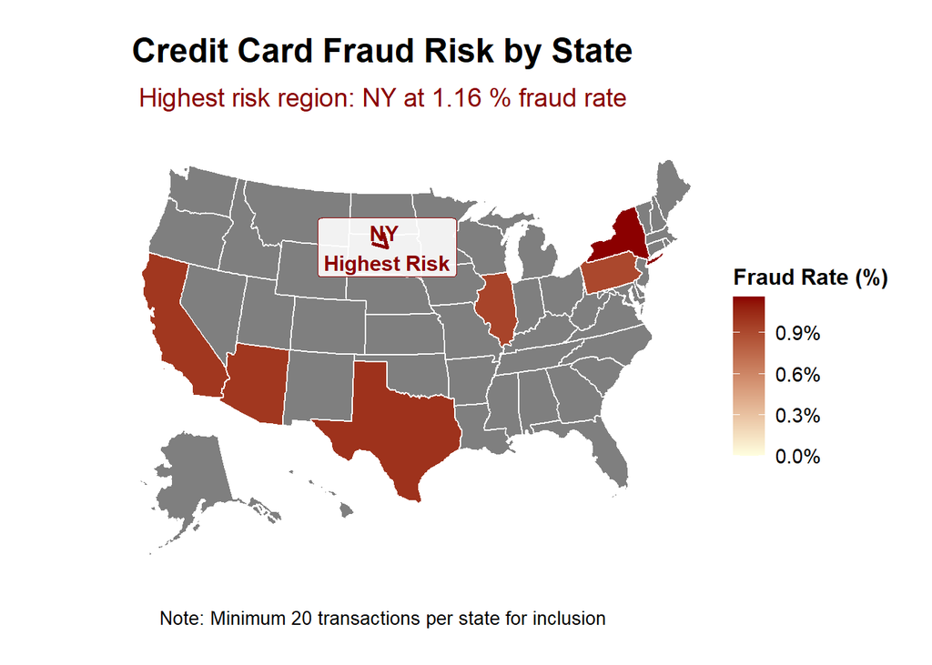

```r
# Prepare coordinate system for state labels
state_coords <- tibble::tribble(
  ~state, ~x,     ~y,
  "AL",   -86.8,  32.8, "AK",   -152.0, 64.0, "AZ",   -112.0, 34.0, "AR",   -92.2,  34.8,
  "CA",   -120.0, 37.0, "CO",   -105.5, 39.0, "CT",   -72.7,  41.6, "DE",   -75.5,  39.0,
  "FL",   -81.5,  28.0, "GA",   -83.5,  32.5, "HI",   -157.8, 21.3, "ID",   -114.0, 44.0,
  "IL",   -89.0,  40.0, "IN",   -86.0,  39.5, "IA",   -93.5,  42.0, "KS",   -98.0,  38.5,
  "KY",   -85.0,  37.5, "LA",   -92.0,  31.0, "ME",   -69.5,  45.0, "MD",   -76.5,  39.0,
  "MA",   -71.5,  42.3, "MI",   -85.0,  44.5, "MN",   -94.0,  46.0, "MS",   -89.5,  32.5,
  "MO",   -92.5,  38.5, "MT",   -110.0, 47.0, "NE",   -99.5,  41.5, "NV",   -117.0, 39.0,
  "NH",   -71.5,  44.0, "NJ",   -74.5,  40.0, "NM",   -106.0, 34.5, "NY",   -74.0,  43.0,
  "NC",   -79.0,  35.5, "ND",   -100.0, 47.5, "OH",   -82.5,  40.0, "OK",   -97.0,  35.5,
  "OR",   -120.5, 44.0, "PA",   -77.0,  41.0, "RI",   -71.5,  41.7, "SC",   -81.0,  34.0,
  "SD",   -100.0, 44.5, "TN",   -86.0,  36.0, "TX",   -100.0, 31.0, "UT",   -111.5, 39.5,
  "VT",   -72.5,  44.0, "VA",   -78.0,  37.5, "WA",   -120.5, 47.5, "WV",   -80.5,  38.5,
  "WI",   -89.5,  44.5, "WY",   -107.5, 43.0
)

# Get coordinates for highest risk state
label_coords <- state_coords %>%
  filter(state == top_state) %>%
  select(x, y) %>%
  as.list()

# Prepare data for mapping
plot_data <- fraud_by_state %>% rename(state = State)
max_rate <- max(plot_data$FraudRate, na.rm = TRUE)

# Create choropleth map
fraud_map <- plot_usmap(data = plot_data, values = "FraudRate", color = "white", size = 0.3) +
  scale_fill_continuous(
    low = "lightyellow",
    high = "darkred",
    name = "Fraud Rate (%)",
    labels = scales::percent_format(scale = 1, accuracy = 0.1),
    limits = c(0, max_rate)
  ) +
  labs(
    title = "Credit Card Fraud Risk by State",
    subtitle = paste("Highest risk region:", top_state, "at", top_rate, "% fraud rate"),
    caption = "Note: Minimum 20 transactions per state for inclusion"
  ) +
  theme_void() +
  theme(
    plot.title = element_text(size = 18, face = "bold", hjust = 0.5, margin = margin(b = 10)),
    plot.subtitle = element_text(size = 14, hjust = 0.5, color = "darkred", margin = margin(b = 15)),
    plot.caption = element_text(size = 10, hjust = 0.5, margin = margin(t = 15)),
    legend.position = "right",
    legend.text = element_text(size = 11),
    legend.title = element_text(size = 12, face = "bold"),
    plot.margin = margin(20, 20, 20, 20)
  ) +
  annotate("label", x = label_coords$x, y = label_coords$y,
           label = paste(top_state, "\nHighest Risk"), size = 4, fontface = "bold",
           fill = "white", color = "darkred", alpha = 0.9) +
  annotate("segment", x = label_coords$x, xend = label_coords$x + 3,
           y = label_coords$y, yend = label_coords$y - 3,
           color = "darkred", size = 1, arrow = arrow(length = unit(0.3, "cm")))

print(fraud_map)
```

```r
safe_ggsave("state_fraud_risk_map.png", fraud_map, width = 12, height = 8)
```

## Merchant Risk Analysis in Highest-Risk State

**Purpose:** Identify specific merchants within the highest-risk state that demonstrate elevated fraud patterns requiring enhanced monitoring.

**Methodology:** Focus analysis on NY to drill down from geographic risk to merchant-specific patterns. We apply statistical reliability filters and calculate both absolute fraud counts and rates to provide comprehensive risk assessment.

```r
# Validate merchant name quality
is_invalid_name <- function(x) {
  is.na(x) | str_trim(x) == "" | tolower(str_trim(x)) %in% c("na", "n/a", "unknown", "#n/a")
}

# Assess merchant data quality in highest risk state
data_quality_check <- creditCardFraud %>%
  filter(State == top_state) %>%
  summarise(
    total_transactions = n(),
    fraud_cases = sum(IsFraud),
    invalid_merchant_names = sum(is_invalid_name(MerchantName)),
    pct_invalid_names = round(100 * invalid_merchant_names / total_transactions, 1)
  )

cat("Data Quality Assessment for", top_state, ":\n")
```

```
## Data Quality Assessment for NY :
```

```r
cat("Total transactions:", data_quality_check$total_transactions, "\n")
```

```
## Total transactions: 9993
```

```r
cat("Invalid merchant names:", data_quality_check$invalid_merchant_names,
    "(", data_quality_check$pct_invalid_names, "%)\n\n")
```

```
## Invalid merchant names: 521 ( 5.2 %)
```

```r
# Calculate merchant fraud statistics
merchant_analysis <- creditCardFraud %>%
  filter(State == top_state) %>%
  filter(!is_invalid_name(MerchantName)) %>%
  group_by(MerchantName) %>%
  summarise(
    TotalTransactions = n(),
    FraudCases = sum(IsFraud),
    FraudRate = round(100 * FraudCases / TotalTransactions, 1),
    .groups = "drop"
  ) %>%
  filter(TotalTransactions >= 10) %>%  # Minimum sample size for reliability
  arrange(desc(FraudRate))

# Display top risk merchants
top_merchants_table <- head(merchant_analysis, 10)
knitr::kable(top_merchants_table,
             caption = paste("Top 10 Merchants by Fraud Rate in", top_state, "(Min. 10 transactions)"))
```

Top 10 Merchants by Fraud Rate in NY (Min. 10 transactions)

| MerchantName | TotalTransactions | FraudCases | FraudRate |
| --- | --- | --- | --- |
| Golden Hill Corporation | 10 | 1 | 10.0 |
| Sunny Hill Corporation | 24 | 2 | 8.3 |
| Happy Hill Group | 13 | 1 | 7.7 |
| Red Creek Corporation | 17 | 1 | 5.9 |
| Royal River Co. | 26 | 1 | 3.8 |
| Bright River Corporation | 109 | 4 | 3.7 |
| Grand Valley Limited | 111 | 4 | 3.6 |
| Green Cove Group | 28 | 1 | 3.6 |
| Bright River Associates | 156 | 5 | 3.2 |
| Bright River Holdings | 36 | 1 | 2.8 |

```r
# Identify highest risk merchant
top_merchant <- merchant_analysis$MerchantName[1]
top_merchant_rate <- merchant_analysis$FraudRate[1]
```

**Key Finding:** Within NY, Golden Hill Corporation demonstrates the highest fraud rate at 10%, indicating need for enhanced monitoring protocols.

## Merchant Risk Visualization

**Purpose:** Provide clear visual representation of merchant-level fraud risks to support operational decision-making.

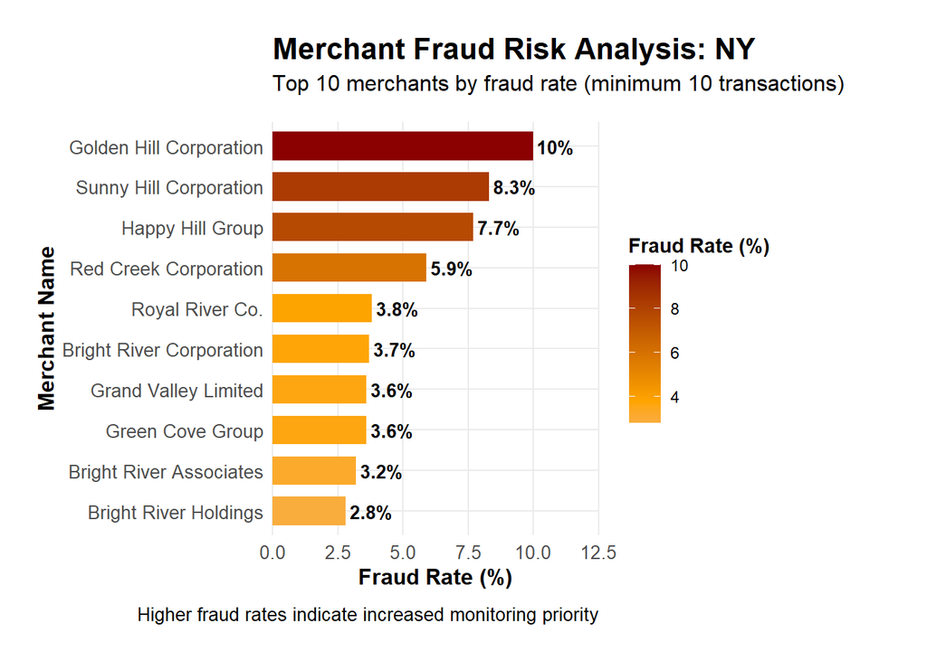

```r
# Prepare data for visualization
viz_data <- head(merchant_analysis, 10) %>%
  mutate(MerchantName = factor(MerchantName, levels = rev(MerchantName)))

# Create merchant fraud rate visualization
merchant_plot <- ggplot(viz_data, aes(x = MerchantName, y = FraudRate, fill = FraudRate)) +
  geom_col(width = 0.7) +
  scale_fill_gradient2(low = "lightblue", mid = "orange", high = "darkred",
                       midpoint = median(viz_data$FraudRate), name = "Fraud Rate (%)") +
  geom_text(aes(label = paste0(FraudRate, "%")), hjust = -0.1, size = 3.5, fontface = "bold") +
  coord_flip(clip = "off") +
  scale_y_continuous(expand = expansion(mult = c(0, 0.25))) +
  labs(
    title = paste("Merchant Fraud Risk Analysis:", top_state),
    subtitle = "Top 10 merchants by fraud rate (minimum 10 transactions)",
    x = "Merchant Name",
    y = "Fraud Rate (%)",
    caption = "Higher fraud rates indicate increased monitoring priority"
  ) +
  theme_minimal() +
  theme(
    plot.title = element_text(size = 16, face = "bold", margin = margin(b = 5)),
    plot.subtitle = element_text(size = 12, margin = margin(b = 15)),
    plot.caption = element_text(size = 10, margin = margin(t = 10)),
    axis.title = element_text(size = 12, face = "bold"),
    axis.text = element_text(size = 10),
    axis.text.y = element_text(hjust = 1),
    legend.position = "right",
    legend.title = element_text(face = "bold"),
    panel.grid.minor = element_blank(),
    plot.margin = margin(20, 80, 20, 20)
  )

print(merchant_plot)
```

```r
safe_ggsave(paste0("merchant_fraud_analysis_", tolower(top_state), ".png"),
           merchant_plot, width = 10, height = 6)
```

## Temporal Fraud Pattern Analysis

**Purpose:** Identify temporal patterns in fraud activity to optimize monitoring resources and detect seasonal trends.

**Methodology:** Multi-scale temporal analysis examining daily volatility, weekly patterns, and monthly trends with statistical smoothing to reduce noise and highlight underlying patterns.

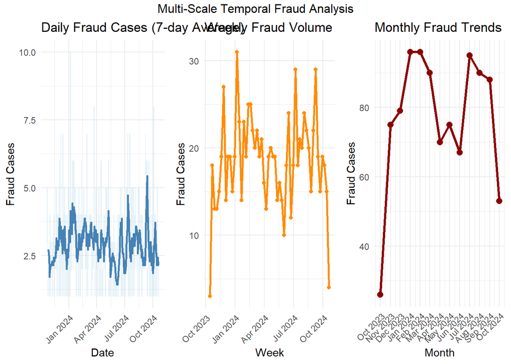

```r
# Prepare temporal data
creditCardFraud <- creditCardFraud %>%
  mutate(TransactionDate_Clean = as.Date(parse_date_time(TransactionDate,
                                        orders = c("mdy HMS", "mdy HM", "mdy"))))

# Daily fraud analysis with smoothing
daily_fraud <- creditCardFraud %>%
  filter(IsFraud == 1) %>%
  group_by(TransactionDate_Clean) %>%
  summarise(FraudCount = n(), .groups = "drop") %>%
  arrange(TransactionDate_Clean) %>%
  mutate(FraudCount_7day = zoo::rollmean(FraudCount, k = 7, fill = NA, align = "right"))

# Weekly aggregation
weekly_fraud <- daily_fraud %>%
  mutate(WeekStart = floor_date(TransactionDate_Clean, "week")) %>%
  group_by(WeekStart) %>%
  summarise(FraudCount = sum(FraudCount), .groups = "drop")

# Monthly aggregation
monthly_fraud <- daily_fraud %>%
  mutate(Month = floor_date(TransactionDate_Clean, "month")) %>%
  group_by(Month) %>%
  summarise(FraudCount = sum(FraudCount), .groups = "drop")

# Create temporal visualizations
p1 <- ggplot(daily_fraud, aes(x = TransactionDate_Clean)) +
  geom_line(aes(y = FraudCount), alpha = 0.3, color = "lightblue") +
  geom_line(aes(y = FraudCount_7day), color = "steelblue", size = 1) +
  labs(title = "Daily Fraud Cases (7-day Average)", x = "Date", y = "Fraud Cases") +
  theme_minimal() +
  theme(axis.text.x = element_text(angle = 45, hjust = 1))

p2 <- ggplot(weekly_fraud, aes(x = WeekStart, y = FraudCount)) +
  geom_line(color = "darkorange", size = 1) +
  geom_point(color = "darkorange", size = 1.5) +
  labs(title = "Weekly Fraud Volume", x = "Week", y = "Fraud Cases") +
  theme_minimal() +
  theme(axis.text.x = element_text(angle = 45, hjust = 1))

p3 <- ggplot(monthly_fraud, aes(x = Month, y = FraudCount)) +
  geom_line(color = "darkred", size = 1.2) +
  geom_point(color = "darkred", size = 2.5) +
  scale_x_date(date_labels = "%b %Y", date_breaks = "1 month") +
  labs(title = "Monthly Fraud Trends", x = "Month", y = "Fraud Cases") +
  theme_minimal() +
  theme(axis.text.x = element_text(angle = 45, hjust = 1))

# Display combined temporal analysis
grid.arrange(p1, p2, p3, ncol = 3,
             top = "Multi-Scale Temporal Fraud Analysis")
```

```r
# Save individual plots
safe_ggsave("daily_fraud_trends.png", p1, width = 8, height = 5)
safe_ggsave("weekly_fraud_trends.png", p2, width = 8, height = 5)
safe_ggsave("monthly_fraud_trends.png", p3, width = 8, height = 5)
```

## Statistical Validation: Bayesian Risk Assessment

**Purpose:** Apply Bayesian statistical methodology to provide statistically-adjusted fraud risk estimates that account for sample size variations and improve reliability of business decisions.

**Methodology:** Bayesian analysis incorporates prior knowledge (overall fraud rate) with observed merchant-specific data to generate posterior probability estimates that are more robust for merchants with smaller transaction volumes.

```r
# Calculate dataset-wide fraud rate as prior
overall_fraud_rate <- mean(creditCardFraud$IsFraud, na.rm = TRUE)

cat("Statistical Foundation:\n")
```

```
## Statistical Foundation:
```

```r
cat("Overall dataset fraud rate (prior):", round(100 * overall_fraud_rate, 2), "%\n")
```

```
## Overall dataset fraud rate (prior): 1 %
```

```r
cat("Total transactions analyzed:", nrow(creditCardFraud), "\n\n")
```

```
## Total transactions analyzed: 100000
```

```r
# Bayesian posterior calculation with Laplace smoothing
compute_bayesian_posterior <- function(fraud_cases, total_cases, prior_rate, alpha = 1, beta = 1) {
  (fraud_cases + alpha * prior_rate) / (total_cases + alpha + beta)
}

# State-level Bayesian analysis
state_bayesian <- creditCardFraud %>%
  filter(!is.na(State), State != "") %>%
  group_by(State) %>%
  summarise(
    TotalCases = n(),
    FraudCases = sum(IsFraud),
    ObservedRate = round(100 * FraudCases / TotalCases, 2),
    BayesianRate = round(100 * compute_bayesian_posterior(FraudCases, TotalCases, overall_fraud_rate), 2),
    .groups = "drop"
  ) %>%
  filter(TotalCases >= 20) %>%
  arrange(desc(BayesianRate))

# Display Bayesian state analysis
cat("Bayesian State Risk Assessment (Top 10):\n")
```

```
## Bayesian State Risk Assessment (Top 10):
```

```r
bayesian_state_table <- head(state_bayesian, 10) %>%
  select(State, TotalCases, FraudCases, ObservedRate, BayesianRate)
knitr::kable(bayesian_state_table,
             caption = "Bayesian-Adjusted State Fraud Risk Assessment")
```

Bayesian-Adjusted State Fraud Risk Assessment

| State | TotalCases | FraudCases | ObservedRate | BayesianRate |
| --- | --- | --- | --- | --- |
| NY | 9993 | 116 | 1.16 | 1.16 |
| TX | 30129 | 303 | 1.01 | 1.01 |
| AZ | 9960 | 99 | 0.99 | 0.99 |
| CA | 29852 | 297 | 0.99 | 0.99 |
| IL | 10193 | 95 | 0.93 | 0.93 |
| PA | 9873 | 90 | 0.91 | 0.91 |

```r
# Merchant-level Bayesian analysis for top risk state
top_bayesian_state <- state_bayesian$State[1]

merchant_bayesian <- creditCardFraud %>%
  filter(State == top_bayesian_state, !is_invalid_name(MerchantName)) %>%
  group_by(MerchantName) %>%
  summarise(
    TotalCases = n(),
    FraudCases = sum(IsFraud),
    ObservedRate = round(100 * FraudCases / TotalCases, 1),
    BayesianRate = round(100 * compute_bayesian_posterior(FraudCases, TotalCases, overall_fraud_rate), 1),
    .groups = "drop"
  ) %>%
  filter(TotalCases >= 10) %>%
  arrange(desc(BayesianRate)) %>%
  slice_head(n = 10)

# Display Bayesian merchant analysis
cat("\nBayesian Merchant Risk Assessment for", top_bayesian_state, ":\n")
```

```
##
## Bayesian Merchant Risk Assessment for NY :
```

```r
bayesian_merchant_table <- merchant_bayesian %>%
  select(MerchantName, TotalCases, FraudCases, ObservedRate, BayesianRate)
knitr::kable(bayesian_merchant_table,
             caption = paste("Bayesian-Adjusted Merchant Risk in", top_bayesian_state))
```

Bayesian-Adjusted Merchant Risk in NY

| MerchantName | TotalCases | FraudCases | ObservedRate | BayesianRate |
| --- | --- | --- | --- | --- |
| Golden Hill Corporation | 10 | 1 | 10.0 | 8.4 |
| Sunny Hill Corporation | 24 | 2 | 8.3 | 7.7 |
| Happy Hill Group | 13 | 1 | 7.7 | 6.7 |
| Red Creek Corporation | 17 | 1 | 5.9 | 5.3 |
| Bright River Corporation | 109 | 4 | 3.7 | 3.6 |
| Royal River Co. | 26 | 1 | 3.8 | 3.6 |
| Grand Valley Limited | 111 | 4 | 3.6 | 3.5 |
| Green Cove Group | 28 | 1 | 3.6 | 3.4 |
| Bright River Associates | 156 | 5 | 3.2 | 3.2 |
| Bright River Holdings | 36 | 1 | 2.8 | 2.7 |

## Bayesian Risk Visualization

**Purpose:** Visualize statistically-adjusted risk estimates to support evidence-based fraud prevention resource allocation.

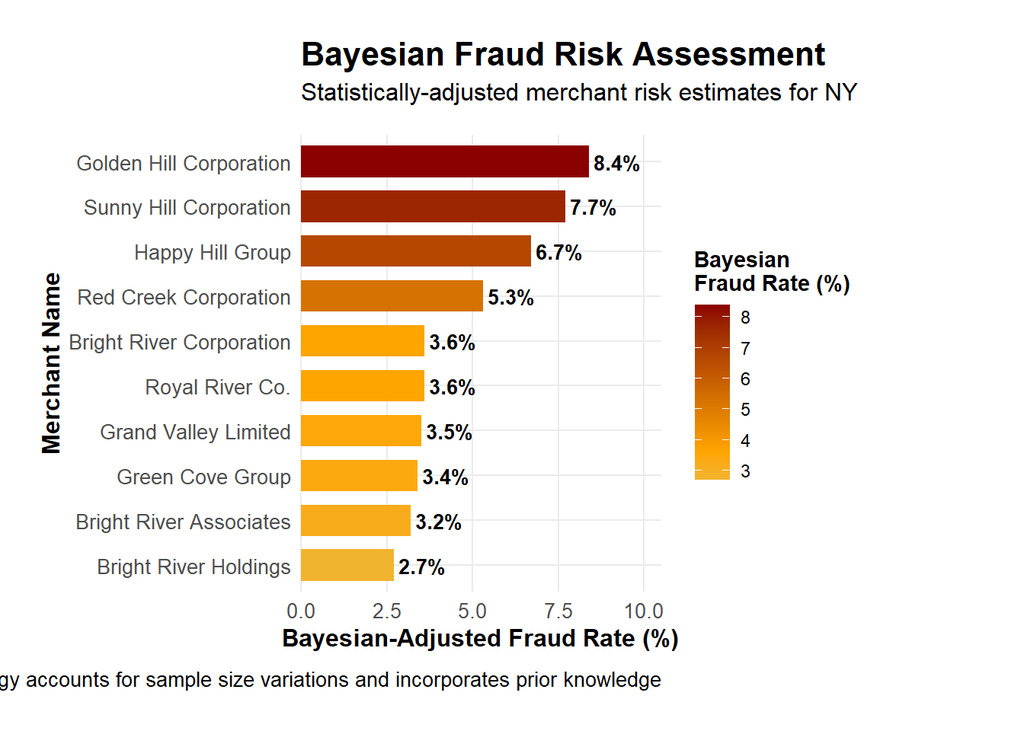

```r
# Prepare Bayesian merchant visualization
bayesian_viz_data <- merchant_bayesian %>%
  mutate(MerchantName = factor(MerchantName, levels = rev(MerchantName)))

# Create Bayesian risk visualization
bayesian_plot <- ggplot(bayesian_viz_data, aes(x = MerchantName, y = BayesianRate, fill = BayesianRate)) +
  geom_col(width = 0.7) +
  scale_fill_gradient2(low = "lightgreen", mid = "orange", high = "darkred",
                       midpoint = median(bayesian_viz_data$BayesianRate),
                       name = "Bayesian\nFraud Rate (%)") +
  geom_text(aes(label = paste0(BayesianRate, "%")), hjust = -0.1, size = 3.5, fontface = "bold") +
  coord_flip(clip = "off") +
  scale_y_continuous(expand = expansion(mult = c(0, 0.25))) +
  labs(
    title = "Bayesian Fraud Risk Assessment",
    subtitle = paste("Statistically-adjusted merchant risk estimates for", top_bayesian_state),
    x = "Merchant Name",
    y = "Bayesian-Adjusted Fraud Rate (%)",
    caption = "Bayesian methodology accounts for sample size variations and incorporates prior knowledge"
  ) +
  theme_minimal() +
  theme(
    plot.title = element_text(size = 16, face = "bold", margin = margin(b = 5)),
    plot.subtitle = element_text(size = 12, margin = margin(b = 15)),
    plot.caption = element_text(size = 10, margin = margin(t = 10)),
    axis.title = element_text(size = 12, face = "bold"),
    axis.text = element_text(size = 10),
    legend.position = "right",
    legend.title = element_text(face = "bold"),
    panel.grid.minor = element_blank(),
    plot.margin = margin(20, 80, 20, 20)
  )

print(bayesian_plot)
```

```r
safe_ggsave("bayesian_merchant_risk_assessment.png", bayesian_plot, width = 12, height = 7)
```

## Key Findings and Strategic Recommendations

### Summary of Analysis Results

**Merchant Risk Patterns:** - Within highest-risk states, specific merchants show substantially elevated fraud rates - Golden Hill Corporation shows highest Bayesian-adjusted risk at 8.4% - Risk concentration enables focused monitoring and intervention strategies

**Temporal Intelligence:** - Multi-scale analysis reveals both short-term volatility and longer-term trends - Patterns support dynamic resource allocation based on temporal fraud cycles - 7-day smoothing reduces noise while preserving actionable trend information

### Implementation Framework

**Strategic Implementation:** 1. **Risk Scoring Integration:** Incorporate Bayesian-adjusted rates into automated fraud detection systems 2. **Dynamic Resource Allocation:** Establish protocols that automatically adjust monitoring based on evidence-derived risk profiles 3. **Continuous Monitoring:** Implement regular re-analysis to detect emerging risk patterns and validate ongoing effectiveness

**Success Metrics:** - Reduction in fraud rates within targeted high-risk geographic regions - Improved fraud detection accuracy through enhanced merchant-level monitoring - Optimized resource utilization aligned with temporal fraud patterns - Overall improvement in fraud prevention ROI through data-driven targeting

### Professional Standards and Reproducibility

This analysis employs industry-standard statistical methodologies and transparent documentation to ensure reproducibility and peer review. All data processing steps are documented with executable code, enabling independent verification of findings. The Bayesian statistical framework provides robust risk estimates that account for sample size variations. This reproducible analysis framework can be adapted for ongoing fraud monitoring and extended to other datasets or geographic regions.